# Analyst - Digital & Data Analytics Practice @ Stout - Case Study

Thai Nhu Anh Nguyen

06/07/2022

```r
# Load libraries
library(tidyverse)
```

```r
library(tidyr)
library(ggplot2)
library(DataExplorer)
library(randomForest)
library(usmap)
library(maps)
library(caret)
```

## Case Study 1

Below is a data set that represents thousands of loans made through the Lending Club platform, which is a platform that allows individuals to lend to other individuals.

```r
# Load the dataset
loans <- read.csv("loans_full_schema.csv", header = TRUE)

# Set Blank to NA
loans[loans == ""] <- NA
```

### (A) Describe the dataset and any issues with it.

```r
dim(loans)
```

```
## [1] 10000    55
```

```r
dim(na.omit(loans))
```

```
## [1] 201  55
```

Therefore, I believe it would be reasonable to remove variables containing too many NAs or irrelevant variables first, then removing observations with NA after. Notice that:

- `emp_title` is irrelevant. (REMOVED)
- `emp_length` has 817 NAs. **(KEEP)**
- `debt_to_income` has 24 NAs. **(KEEP)**
- `annual_income_joint` has 8505 NAs. (REMOVED)
- `verification_income_joint` has 8545 NAs. (REMOVED)
- `debt_to_income_joint` has 8505 NAs. (REMOVED)
- `mpnths_since_last_delinq` has 5658 NAs. (REMOVED)
- `months_since_90d_late` has 7715 NAs. (REMOVED)
- `months_since_last_credit_inquiry` has 1271 NAs. **(KEEP)**
- `num_accounts_120d_past_due` has 318 NAs. **(KEEP)**

```r
output <- c()
# Calculate number of NAs in each columns
for (i in 1:ncol(loans)) {
  output[i] <- length(which(is.na(loans[i])))
}
output
```

```
##  [1]  833  817    0    0    0    0   24 8505 8545 8505    0 5658    0    0    0
## [16]    0    0    0    0    0 7715    0    0    0    0 1271    0  318    0    0
## [31]    0    0    0    0    0    0    0    0    0    0    0    0    0    0    0
## [46]    0    0    0    0    0    0    0    0    0    0
```

```r
# Get the descriptive statistics for number of NAs
# Since the mean is 4595 (excluding irrelevent variable), I believe
# it would be sufficient to remove variables containing 4595 NAs or greater
summary(output[output != 0 & output != 833])
```

```
##    Min. 1st Qu.  Median    Mean 3rd Qu.    Max.
##      24     817    5658    4595    8505    8545
```

```r
loans %>%
  # Remove irrelevant variables or variables containing lots of NAs
  select(-emp_title,
         -annual_income_joint,
         -verification_income_joint,
         -debt_to_income_joint,
         -months_since_last_delinq,
         -months_since_90d_late) %>%
  # Omi NAs
  drop_na() -> loans

# Get the new dimension
dim(loans)
```

```
## [1] 7772   49
```

The dataset now has 7772 observations and 49 variables.

```r
# Retrieve only numeric variables
loans %>%
  select(where(is.numeric), loan_status) -> a

# Calculate the mean
mean <- as.data.frame(apply(a[, -39], 2, function(x) tapply(x, a$loan_status, mean)))
mean
```

```
##                    emp_length annual_income debt_to_income delinq_2y
## Charged Off          6.400000      94976.00       19.52400 0.0000000
## Current              5.901845      83066.22       19.25687 0.2103524
## Fully Paid           6.026882      90198.48       17.89538 0.2284946
## In Grace Period      6.326923      88441.35       19.20038 0.2500000
## Late (16-30 days)    4.733333      78020.23       18.32567 0.2666667
## Late (31-120 days)   5.530612      82976.81       15.84918 0.1836735
##                    earliest_credit_line inquiries_last_12m total_credit_lines
## Charged Off                    2001.200           2.200000           25.80000
## Current                        2001.740           2.251652           23.51156
## Fully Paid                     2001.538           2.465054           25.25269
## In Grace Period                2001.481           2.615385           24.03846
## Late (16-30 days)              2002.400           2.966667           19.53333
## Late (31-120 days)             2003.388           2.326531           18.40816
##                    open_credit_lines total_credit_limit total_credit_utilized
## Charged Off                12.800000           355695.8              82830.40
## Current                    11.843750           195264.8              54216.44
## Fully Paid                 11.642473           223990.4              58448.52
## In Grace Period            11.596154           169849.4              56873.35
## Late (16-30 days)          10.300000           214434.3              53257.33
## Late (31-120 days)          9.061224           142947.9              46982.63
##                    num_collections_last_12m num_historical_failed_to_pay
## Charged Off                      0.00000000                   0.20000000
## Current                          0.01238987                   0.17524780
## Fully Paid                       0.02150538                   0.16397849
## In Grace Period                  0.01923077                   0.07692308
## Late (16-30 days)                0.00000000                   0.16666667
## Late (31-120 days)               0.02040816                   0.14285714
##                    current_accounts_delinq total_collection_amount_ever
## Charged Off                              0                   1188.20000
## Current                                  0                    202.22150
## Fully Paid                               0                    119.15591
## In Grace Period                          0                     74.78846
## Late (16-30 days)                        0                     90.46667
## Late (31-120 days)                       0                     32.00000
##                    current_installment_accounts accounts_opened_24m
## Charged Off                            4.400000            4.600000
## Current                                2.876239            4.750688
## Fully Paid                             2.717742            5.279570
## In Grace Period                        2.557692            4.423077
```

[output cut: 50 more lines]

```
## Late (31-120 days)             0.10204082    19170.92 44.32653      16.40184
##                    installment  balance paid_total paid_principal paid_interest
## Charged Off           366.6520     0.00   874.0260       585.1520      288.8740
## Current               481.5239 15287.07  1914.1383      1286.2055      627.8756
## Fully Paid            459.8121     0.00 16192.1008     15836.1559      355.8476
## In Grace Period       530.4317 16467.70  1690.7571       995.2798      693.1015
## Late (16-30 days)     422.5530 14613.48  1326.7033       623.1903      700.4993
## Late (31-120 days)    586.8957 18751.84   739.8916       419.0747      318.9986
##                    paid_late_fees
## Charged Off            0.00000000
## Current                0.05717098
## Fully Paid             0.09704301
## In Grace Period        2.37576923
## Late (16-30 days)      3.01366667
## Late (31-120 days)     1.81836735
```

```r
# Calculate the minimum values
min <- as.data.frame(apply(a[, -39], 2, function(x) tapply(x, a$loan_status, min)))
min
```

```
##                    emp_length annual_income debt_to_income delinq_2y
## Charged Off                 1         30000           3.82         0
## Current                     0          3000           0.00         0
## Fully Paid                  0         15000           0.00         0
## In Grace Period             0         20000           0.35         0
## Late (16-30 days)           0         14300           0.86         0
## Late (31-120 days)          0         14400           0.00         0
##                    earliest_credit_line inquiries_last_12m total_credit_lines
## Charged Off                        1996                  1                  7
## Current                            1963                  0                  2
## Fully Paid                         1977                  0                  4
## In Grace Period                    1968                  0                  4
## Late (16-30 days)                  1979                  0                  3
## Late (31-120 days)                 1978                  0                  2
##                    open_credit_lines total_credit_limit total_credit_utilized
## Charged Off                        5              43000                 12090
## Current                            0                  0                     0
## Fully Paid                         2               5500                     0
## In Grace Period                    1               5300                   796
## Late (16-30 days)                  2               2500                   279
## Late (31-120 days)                 2               6300                     0
##                    num_collections_last_12m num_historical_failed_to_pay
## Charged Off                               0                            0
## Current                                   0                            0
## Fully Paid                                0                            0
## In Grace Period                           0                            0
## Late (16-30 days)                         0                            0
## Late (31-120 days)                        0                            0
##                    current_accounts_delinq total_collection_amount_ever
## Charged Off                              0                            0
## Current                                  0                            0
## Fully Paid                               0                            0
## In Grace Period                          0                            0
## Late (16-30 days)                        0                            0
## Late (31-120 days)                       0                            0
##                    current_installment_accounts accounts_opened_24m
## Charged Off                                   0                   2
## Current                                       0                   0
## Fully Paid                                    0                   0
## In Grace Period                               0                   0
```

[output cut: 50 more lines]

```
## Late (31-120 days)                      0        5000   36          5.31
##                    installment balance paid_total paid_principal paid_interest
## Charged Off              93.96    0.00       0.00           0.00          0.00
## Current                  30.75    0.00      65.09          40.19         13.81
## Fully Paid               43.17    0.00    1309.08        1300.00          0.00
## In Grace Period          49.97  970.37     400.21         183.24         29.45
## Late (16-30 days)        34.22  954.95      82.66          45.05         22.61
## Late (31-120 days)      169.90 4656.31       0.00           0.00          0.00
##                    paid_late_fees
## Charged Off                     0
## Current                         0
## Fully Paid                      0
## In Grace Period                 0
## Late (16-30 days)               0
## Late (31-120 days)              0
```

```r
# Calculate the maximum values
max <- as.data.frame(apply(a[, -39], 2, function(x) tapply(x, a$loan_status, max)))
max
```

```
##                    emp_length annual_income debt_to_income delinq_2y
## Charged Off                10        169880          34.72         0
## Current                    10       1600001         469.09        13
## Fully Paid                 10       2300000         209.10         4
## In Grace Period            10        700000          44.70         2
## Late (16-30 days)          10        240000          41.51         3
## Late (31-120 days)         10        258000          36.24         2
##                    earliest_credit_line inquiries_last_12m total_credit_lines
## Charged Off                        2008                  3                 47
## Current                            2015                 26                 87
## Fully Paid                         2014                 11                 80
## In Grace Period                    2014                 10                 53
## Late (16-30 days)                  2014                 18                 45
## Late (31-120 days)                 2013                 20                 61
##                    open_credit_lines total_credit_limit total_credit_utilized
## Charged Off                       25             767814                150759
## Current                           46            3386034                873713
## Fully Paid                        51            2761000                942456
## In Grace Period                   38             515401                310894
## Late (16-30 days)                 17             779847                214234
## Late (31-120 days)                28             620222                303858
##                    num_collections_last_12m num_historical_failed_to_pay
## Charged Off                               0                            1
## Current                                   2                           52
## Fully Paid                                2                            3
## In Grace Period                           1                            2
## Late (16-30 days)                         0                            1
## Late (31-120 days)                        1                            1
##                    current_accounts_delinq total_collection_amount_ever
## Charged Off                              0                         5743
## Current                                  0                       199308
## Fully Paid                               0                         7623
## In Grace Period                          0                         2573
## Late (16-30 days)                        0                         1577
## Late (31-120 days)                       0                         1070
##                    current_installment_accounts accounts_opened_24m
## Charged Off                                  13                   9
## Current                                      35                  29
## Fully Paid                                   15                  17
## In Grace Period                              17                  12
```

[output cut: 50 more lines]

```
## Late (31-120 days)                      1       40000   60         30.75
##                    installment  balance paid_total paid_principal paid_interest
## Charged Off             649.30     0.00    1918.96        1439.33        612.52
## Current                1566.59 39308.29   27411.41       26789.71       4216.44
## Fully Paid             1388.82     0.00   41630.44       40000.00       2144.57
## In Grace Period        1298.59 36145.13    5171.20        3854.87       2410.72
## Late (16-30 days)       952.65 38630.01    3399.99        1671.20       2392.01
## Late (31-120 days)     1230.85 40000.00    3375.85        1835.27       1540.58
##                    paid_late_fees
## Charged Off                  0.00
## Current                     42.91
## Fully Paid                  21.10
## In Grace Period             52.98
## Late (16-30 days)           30.41
## Late (31-120 days)          45.12
```

It is also interesting to look at loans divided by terms - 36 months and 60 months.

```r
table(as.factor(loans$loan_status), as.factor(loans$term))
```

```
##
##                        36   60
##   Charged Off           4    1
##   Current            5031 2233
##   Fully Paid          252  120
##   In Grace Period      34   18
##   Late (16-30 days)    15   15
##   Late (31-120 days)   32   17
```

### (B) Generate a minimum of 5 unique visualizations using the data and write a brief description of your observations. Additionally, all attempts should be made to make the visualizations visually appealing

- Loans Grade

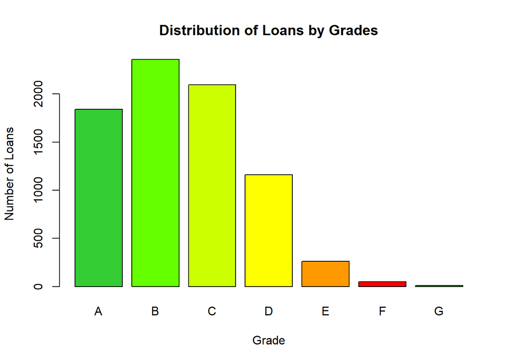

```r
barplot(table(as.factor(loans$grade)),
        main = "Distribution of Loans by Grades",
        xlab = "Grade",
        ylab = "Number of Loans",
        col = c("#33CC33", "#66FF00", "#CCFF00", "#FFFF00", "#FF9900", "#FF0000"))
```

We know that loan grades are set based on both the borrower’s credit profile and the nature of the contract. ‘A’ grade loans represent the lowest risk while ‘G’ grade loans are the riskiest.

According to the graph, most of the loans are at low or acceptable risk, which is a positive result.

- Income Range

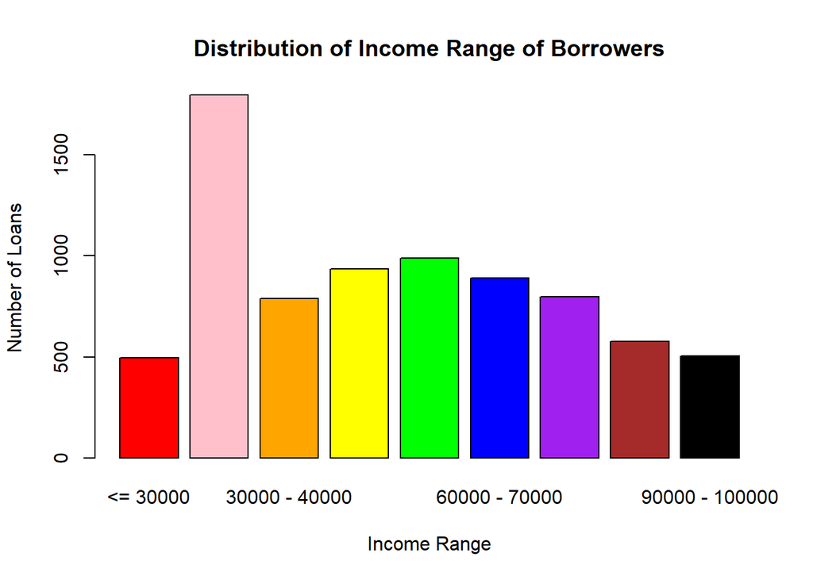

```r
copy_loans <- loans
copy_loans$income_range <- ""

for (i in 1:nrow(copy_loans)) {
  if (copy_loans[i, 4] <= 30000)
    copy_loans$income_range[i] <- "<= 30000"
  else if (copy_loans[i, 4] <= 40000)
    copy_loans$income_range[i] <- "30000 - 40000"
  else if (copy_loans[i, 4] <= 50000)
    copy_loans$income_range[i] <- "40000 - 50000"
  else if (copy_loans[i, 4] <= 60000)
    copy_loans$income_range[i] <- "50000 - 60000"
  else if (copy_loans[i, 4] <= 70000)
    copy_loans$income_range[i] <- "60000 - 70000"
  else if (copy_loans[i, 4] <= 80000)
    copy_loans$income_range[i] <- "70000 - 80000"
  else if (copy_loans[i, 4] <= 90000)
    copy_loans$income_range[i] <- "80000 - 90000"
  else if (copy_loans[i, 4] <= 100000)
    copy_loans$income_range[i] <- "90000 - 100000"
  else
    copy_loans$income_range[i] <- "> 100000"
}

plot(as.factor(copy_loans$income_range),
    main = "Distribution of Income Range of Borrowers",
     xlab = "Income Range",
     ylab = "Number of Loans",
     col = c("red", "pink", "orange", "yellow", "green", "blue", "purple", "brown", "black"))
```

- Relationship between Income Range and Loan Purposes

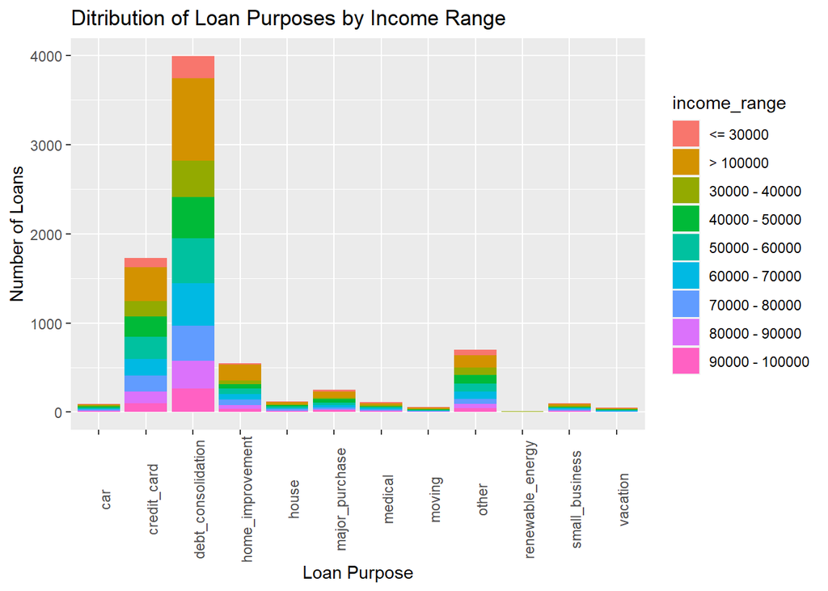

```r
ggplot(data = copy_loans, mapping = aes(x = loan_purpose, fill = income_range)) +
  geom_bar() +
  theme(axis.text.x = element_text(angle = 90)) +
  ggtitle("Ditribution of Loan Purposes by Income Range") +
  xlab("Loan Purpose") + ylab("Number of Loans")
```

According to the graph, most loans are for credit card and debt consolidation, of which > $100,000 annual income makes up the most portion.

- Loan Condition

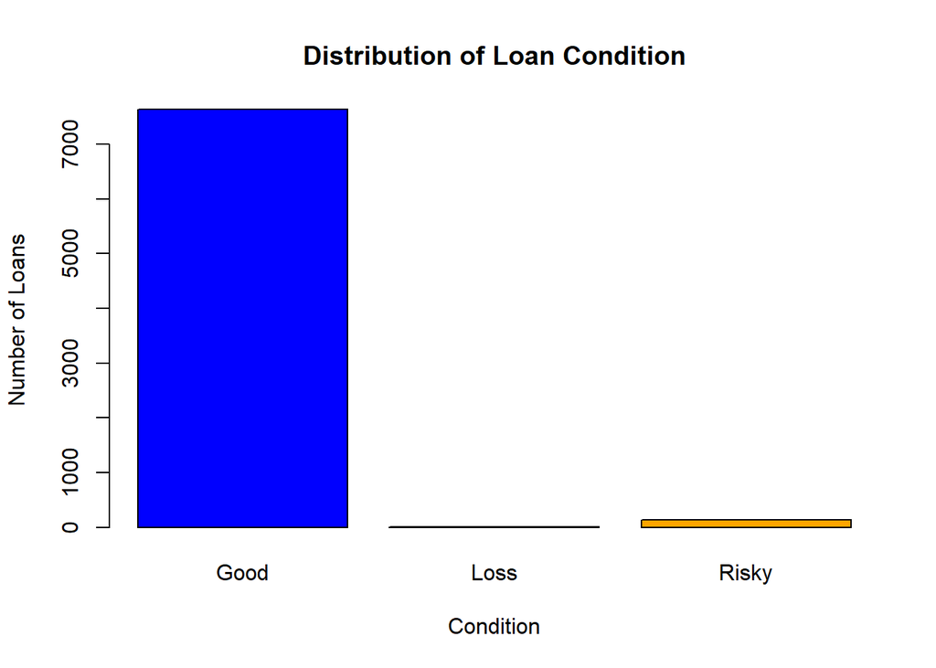

```r
copy_loans$loan_condition <- ""

for (i in 1:nrow(copy_loans)) {
  if (copy_loans[i, 42] == "Charged Off")
    copy_loans$loan_condition[i] <- "Loss"
  else if (copy_loans[i, 42] == "Current")
    copy_loans$loan_condition[i] <- "Good"
  else if (copy_loans[i, 42] == "Fully Paid")
    copy_loans$loan_condition[i] <- "Good"
  else
    copy_loans$loan_condition[i] <- "Risky"
}

barplot(table(as.factor(copy_loans$loan_condition)),
    main = "Distribution of Loan Condition",
    xlab = "Condition",
    ylab = "Number of Loans",
    col = c("blue1", "red", "orange"))
```

Most of the loans are in good condition, meaning the platform is safe and the borrowers have high chance to pay back.

- Plot of Correlation

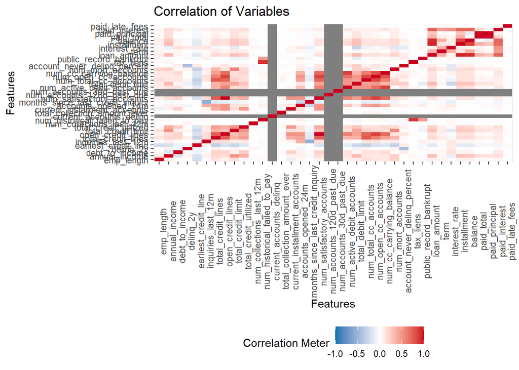

```r
# Plot Correlation Heatmap
plot_correlation(loans, type = 'continuous',
                 title = "Correlation of Variables")
```

```r
a <- loans %>%
  select(where(is.numeric))
# Since the numbers are small, retrieving the correlation
# cor(a) --- Correlation of all variables
# cor(a) > 0.5 & cor(a) < 1 --- High correlation only
# Due to a large number of rows, please view it at your own wish
```

According to the correlation heatmap, here are some significant highly correlated variables:

- `open_credit_lines` with `total_credit_lines`, `current_installment_accounts`, `num_satisfactory_accounts`, `num_active_debit_accounts`, `num_total_cc_accounts`, `num_open_cc_accounts`, `num_cc_carrying_balance`.
- `total_credit_limit` with `annual_income`, `total_credit_utilized`, `num_mort_accounts`
- Especially, `interest_rate` with `paid_interest`

The results are reasonable when compared to descriptions in Lending Clubs.

- Plot of Loans by States

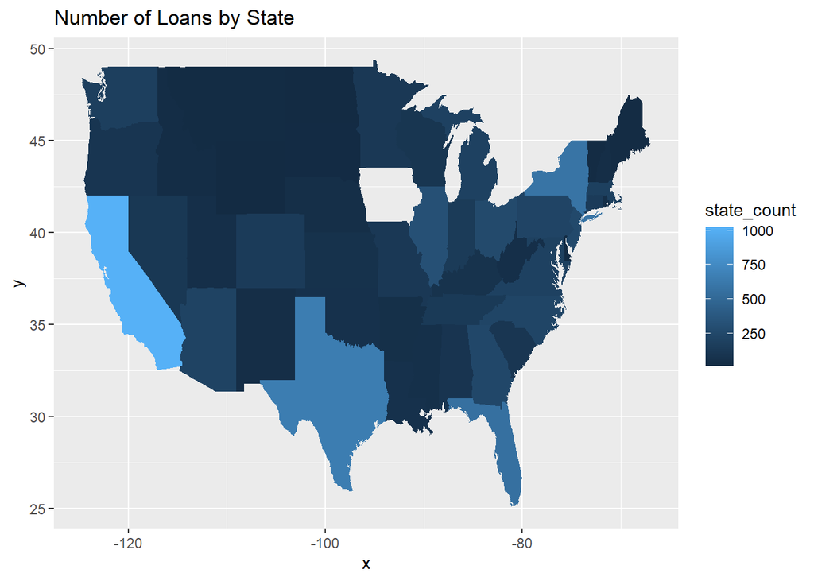

```r
us_states <- map_data("state")
loans %>%
  mutate(states = state.name[match(state, state.abb)]) %>%
  mutate(states = str_to_lower(states)) %>%
  group_by(states) %>%
  mutate(state_count = n()) %>%
  select(states, state_count) %>%
  unique() %>%
  ggplot() +
  geom_map(map = us_states, aes(map_id = states, fill = state_count)) +
  expand_limits(x = us_states$long, y = us_states$lat)  +
  labs(title = "Number of Loans by State")
```

According to the map, California, Texas, New York, and Florida has the most number of loans.

### (C) Create a feature set and create a model which predicts interest_rate using at least 2 algorithms. Describe any data cleansing that must be performed and analysis when examining the data.

## Random Forest with all variables

```r
set.seed(1)
# Generate a random sample
i.train <- sample(1:nrow(loans), 0.7 * nrow(loans))
loans.train <- loans[i.train, ]
loans.test <- loans[-i.train, ]
```

```r
# 5 fold CV
control <- trainControl(method='repeatedcv',
                        number=5, # 10
                        repeats=1) # 3
set.seed(2022)

# Number randomly variable selected is mtry
mtry <- sqrt(ncol(loans.train))
tunegrid <- expand.grid(.mtry=mtry)
rf_mod <- train(interest_rate ~.,
                      data=loans.train,
                      method='rf',
                      tuneGrid=tunegrid,
                      trControl=control)
rf_mod
```

```
## Random Forest
##
## 5440 samples
##   48 predictor
##
## No pre-processing
## Resampling: Cross-Validated (5 fold, repeated 1 times)
## Summary of sample sizes: 4352, 4352, 4351, 4352, 4353
## Resampling results:
##
##   RMSE      Rsquared   MAE
##   1.417913  0.9606613  0.9899497
##
## Tuning parameter 'mtry' was held constant at a value of 7
```

```r
# Predict interest rate using random forest on loans test dataset
rf_prediction <- predict(rf_mod, subset(loans.test, select = -c(interest_rate)))

# Finding the RMSE
sqrt(mean((rf_prediction - loans.test$interest_rate)^2))
```

```
## [1] 1.25298
```

Since the RMSE (Root Mean Square Error) is a metric that tells us the average distance between the predicted values from the model and the actual values in the dataset, the lower the RMSE, the better the model fits a dataset. Here, the RMSE is 1.25298, which is a relatively low RMSE, meaning Random Forest on all variables is a good fit.

## Random Forest with Only Important Variables

After consideration, I believe Random Forest on Important Variables Selected might give a better RMSE. Thus, I perform Random Forest Variable Selection to pick most important variables that correlate with `interest_rate`.

- Using Random Forest Built-in Function

```r
set.seed(2022)
# Performing Random Forest Variable Selection
rf <- randomForest(interest_rate ~., data = loans.train)
#summary(rf)

# Get the importance of variables in descending level
# i.e the first is the least important
head(importance(rf)[order(importance(rf)), ], 20)
```

```
##      current_accounts_delinq   num_accounts_120d_past_due
##                    0.0000000                    0.0000000
##    num_accounts_30d_past_due               paid_late_fees
##                    0.0000000                    0.2262252
##     num_collections_last_12m       public_record_bankrupt
##                    1.6217299                    3.7292545
##                    tax_liens num_historical_failed_to_pay
##                    4.3007022                    5.6612170
##             application_type                homeownership
##                    8.8939874                   13.1114898
##                    delinq_2y current_installment_accounts
##                   21.1381954                   25.3930343
## total_collection_amount_ever                   emp_length
##                   27.3275714                   28.7112524
##                 loan_purpose    num_satisfactory_accounts
##                   29.3770287                   30.5210796
##            open_credit_lines                  issue_month
##                   30.6489678                   31.1887195
##         num_open_cc_accounts                  loan_status
##                   34.5913238                   36.4894212
```

```r
# Now, get only 10 most important variables
importance(rf)[rev(order(importance(rf))), ][1:10]
```

```
##         sub_grade             grade     paid_interest              term
##        69801.0525        52061.3672         6827.2851         2727.1807
##    paid_principal total_debit_limit        paid_total       installment
##         1752.0734         1436.8393          479.3779          414.2999
##       loan_amount           balance
##          402.0970          397.7773
```

- Using Random Forest & Cross Validation

```r
# Variable Importance
rf_imp <- varImp(rf_mod, scale = TRUE)
rf_imp
```

```
## rf variable importance
##
##   only 20 most important variables shown (out of 147)
##
##                   Overall
## gradeD             100.00
## paid_interest       68.55
## gradeE              64.20
## gradeC              37.09
## gradeB              29.50
## term                27.63
## sub_gradeD5         24.42
## total_debit_limit   22.17
## paid_principal      20.52
## gradeF              19.82
## sub_gradeA2         19.06
## sub_gradeA3         17.26
## sub_gradeE5         17.08
## sub_gradeA4         15.96
## paid_total          12.96
## sub_gradeD4         12.71
## sub_gradeD3         12.55
## installment         11.88
## debt_to_income      10.51
## balance             10.17
```

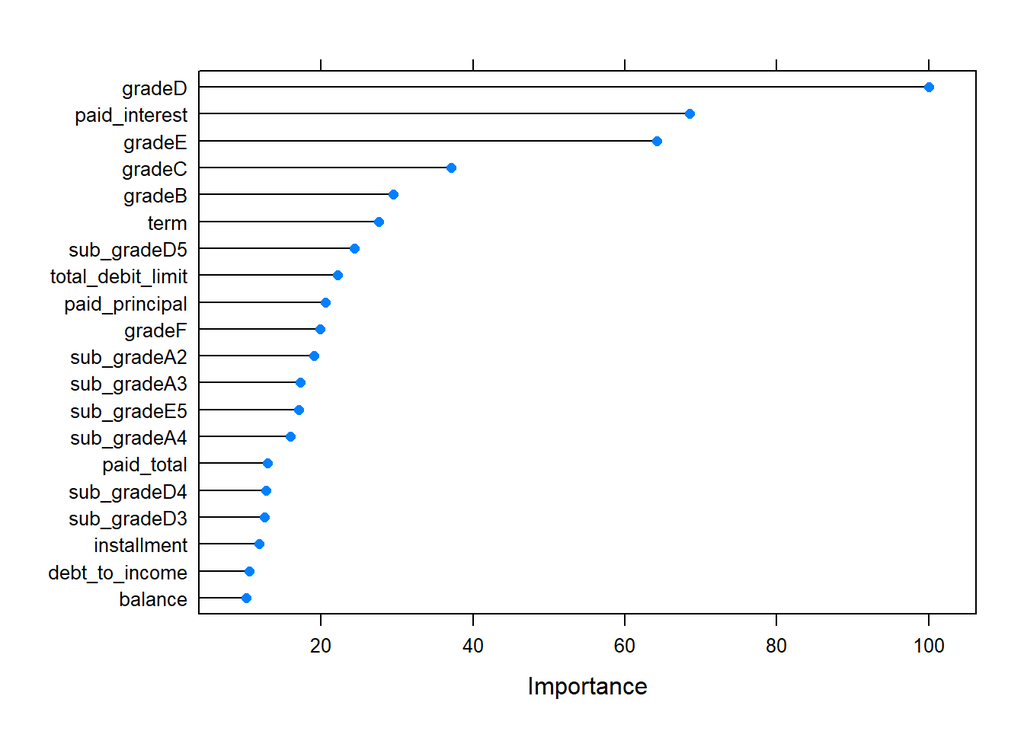

```r
plot(rf_imp, top = 20)
```

- Perform Random Forest Prediction

```r
# Remove variables to only keep the most important ones
included_vars <- c("sub_grade", "grade", "paid_interest", "term", "paid_principal", "total_debit_limit", "paid_total", "installment", "loan_amount", "balance", "interest_rate")

# Update data sets
loans.test <- loans.test %>% select(included_vars)
```

```
## Note: Using an external vector in selections is ambiguous.
## i Use `all_of(included_vars)` instead of `included_vars` to silence this message.
## i See <https://tidyselect.r-lib.org/reference/faq-external-vector.html>.
```

```r
loans.train <- loans.train %>% select(included_vars)
```

```r
# 5 fold CV
control <- trainControl(method='repeatedcv',
                        number=5, # 10
                        repeats=1) # 3
set.seed(2022)

# Number randomly variable selected is mtry
mtry <- sqrt(ncol(loans.train))
tunegrid <- expand.grid(.mtry=mtry)
rf_mod <- train(interest_rate ~.,
                      data=loans.train,
                      method='rf',
                      tuneGrid=tunegrid,
                      trControl=control)
rf_mod
```

```
## Random Forest
##
## 5440 samples
##   10 predictor
##
## No pre-processing
## Resampling: Cross-Validated (5 fold, repeated 1 times)
## Summary of sample sizes: 4352, 4352, 4351, 4352, 4353
## Resampling results:
##
##   RMSE      Rsquared   MAE
##   1.492203  0.9547189  1.10284
##
## Tuning parameter 'mtry' was held constant at a value of 3.316625
```

```r
# Predict interest rate using random forest on loans test dataset
rf_prediction <- predict(rf_mod, subset(loans.test, select = -c(interest_rate)))

# Finding the RMSE
sqrt(mean((rf_prediction - loans.test$interest_rate)^2))
```

```
## [1] 1.371707
```

With an RMSE of 1.371707, Random Forest with Important Variables does not beat the Random Forest on all variables.

## Gradient Boosting Machine

- Perform Gradient Boosting Machine on Important Variables

```r
# Fit the model on the training set
set.seed(1)
gbm.fit <- train(interest_rate ~., data = loans.test, method = "gbm", trControl = trainControl("cv", number = 10))
# Make predictions on the test data
gbm.pred <- predict(gbm.fit, loans.test)

# Finding the RMSE
sqrt(mean((gbm.pred - loans.test$interest_rate)^2))
```

```
## [1] 0.9486632
```

- Perform Gradient Boosting on Full Variables

```r
set.seed(1)
# Generate a random sample
i.train <- sample(1:nrow(loans), 0.7 * nrow(loans))
loans.train <- loans[i.train, ]
loans.test <- loans[-i.train, ]

# Fit the model on the training set
set.seed(1)
gbm.fit <- train(interest_rate ~., data = loans.test, method = "gbm", trControl = trainControl("cv", number = 10))
# Make predictions on the test data
gbm.pred <- predict(gbm.fit, loans.test)

# Finding the RMSE
sqrt(mean((gbm.pred - loans.test$interest_rate)^2))
```

```
## [1] 0.9522241
```

With an RMSE of 0.9522241, this model beats Random Forest, however, it is not the best model to predict interest rate.

### (D) Visualize the test results and propose enhancements to the model, what would you do if you had more time. Also describe assumptions you made and your approach.

```r
table <- matrix(c(0.9522241, 0.9486632, 1.25298, 1.371707), nrow = 2, byrow = T)
row.names(table) <- c("Gradient Boosting Machine", "Random Forest")
colnames(table) <- c("w/ All Vars", "w/ Important Vars")
print(table)
```

```
##                           w/ All Vars w/ Important Vars
## Gradient Boosting Machine   0.9522241         0.9486632
## Random Forest               1.2529800         1.3717070
```

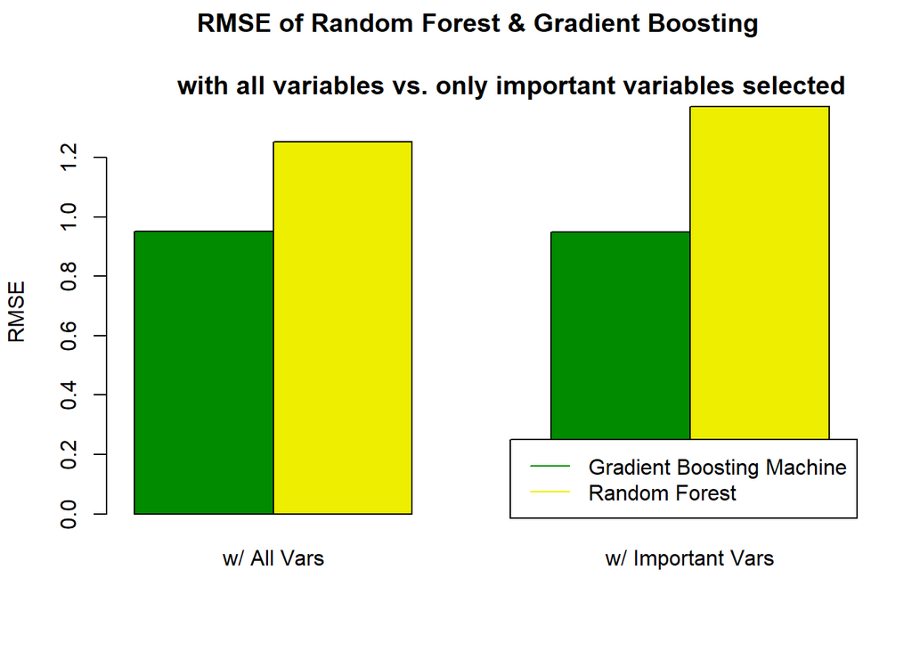

```r
barplot(table, beside = TRUE,
        main = "RMSE of Random Forest & Gradient Boosting \n
        with all variables vs. only important variables selected",
        ylab = "RMSE",
        col = c("green4", "yellow2"))
legend(x = "bottomright",
       legend = c("Gradient Boosting Machine", "Random Forest"),
       col = c("green4", "yellow2"),
       lty = c(1, 1))
```

Due to time constraint, I am not able to test more models to find the possible lowest RMSE that best fits the dataset. Also, my approaches are possible since I assume NAs are not significant, hence being removed from the dataset. If I had more time, I would perform Missing Values Imputation to replace NAs and take them into account.